# Visualizations

- [ggplot2 book](https://ggplot2-book.org/)
  - [ggplot2 documentation](https://ggplot2.tidyverse.org/reference/index.html)
- [R for Data Science](https://r4ds.had.co.nz/)
- [Visualizing Baseball](https://bayesball.github.io/VB/)

Most of the graphs we are going to create use pitch-by-pitch data. We will access Statcast data using the **baseballr** package.

```r
library(tidyverse)
library(baseballr)
```

There are two main data frames that we will use.

First, is Statcast data for Aaron Judge from the entire 2022 season:

```r
judge <- statcast_search(start_date = "2022-04-05", end_date= "2022-10-23", playerid = 592450)
```

Second, is pitch-by-pitch data from a single game. The game chosen is from May 8, 2022 Seattle Mariners vs. Tampa Bay Rays. This was George Kirby’s MLB debut!

```r
game <- statcast_search(start_date = "2022-05-08",
                        end_date = "2022-05-08")
game <- game %>%
  filter(home_team == "SEA")
```

A list of the Statcast variables and their definitions can be found [here](https://baseballsavant.mlb.com/csv-docs).

## Strike Zone Plot

One of the key parts of a strike zone plot is the strike zone. The `geom_rect()` function plots filled-in rectangles. It requires the arguments xmin, xmax, ymin, and ymax. We need to the the strike zone to be specific to Judge, so we will use the median top (sz_top) and median bottom (sz_bot) strike zone values from the data. There are other arguments that are optional. For example, ‘alpha’ controls the transparency of the plotted geom. Since we want the strike zone to be just the outline of the rectangle, alpha is set to 0.

Here is graph of Aaron Judge’s strike zone for pitches that were called a strike or ball by the umpire. A subset of the `judge` data frame was made that only has balls, called_strikes, and that do not have a missing value for the strike zone height.

- `geom_point()` is used to make scatter plots. I am mapping plate_x to the x-axis and plate_z to the y-axis. Since the color is based on a variable (in this case if the call was a ball or a strike) it needs to go inside of aes().
- `geom_rect()` makes the box.
- `labs()` lets you change things like the title, subtitle, axis labels.
- If you want the graph to use specific colors use the `scale_color_manual()` function. A list of colors can be found [here](http://www.stat.columbia.edu/~tzheng/files/Rcolor.pdf).
- `coord_fixed()` keeps the ratio of the graph fixed regardless of the size of the graph.
- `theme_bw()` makes the plot have a white background with light grey grid lines.
- `theme(legend.position = "none")` hides the key explaining what each color is representing.
- `facet_wrap()` splits the plots by whatever variable is specified. In this case, balls and strikes each have their own separate graph.

```r
judge_filter <- judge %>%
  filter(description %in% c("ball", "called_strike"), !is.na(sz_top), !is.na(sz_bot))
```

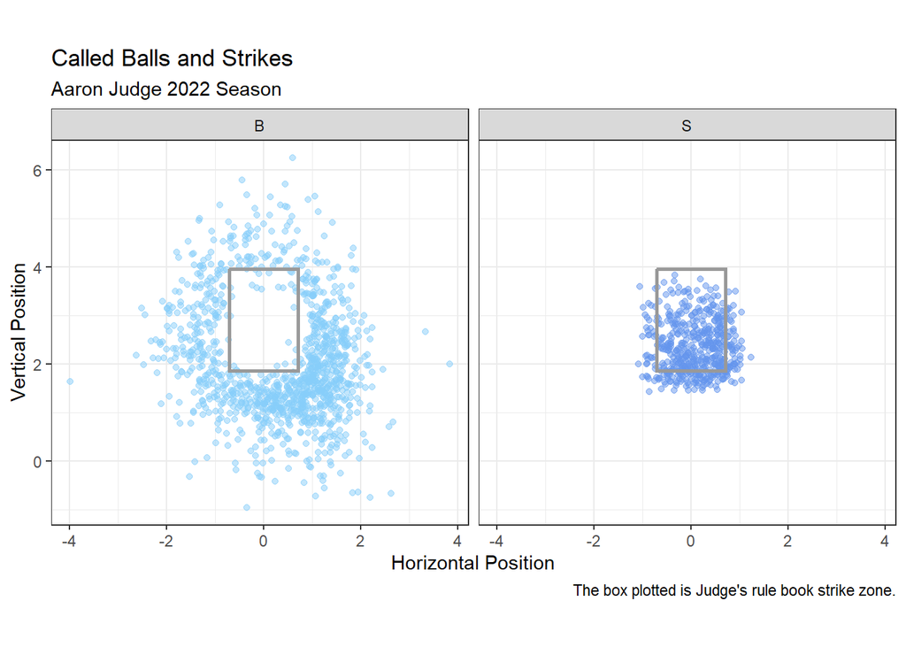

```r
judge_filter %>%
  filter(description %in% c("ball", "called_strike"), !is.na(sz_top), !is.na(sz_bot)) %>%
  ggplot() +
  geom_point(aes(x = plate_x, y = plate_z, color = type), alpha = 0.5) +
  geom_rect(aes(xmin = -.7083, xmax = .7083, ymin = median(sz_bot), ymax = median(sz_top)),
            alpha = 0, color = "gray60", linewidth = 1) +
  labs(title = "Called Balls and Strikes", subtitle = "Aaron Judge 2022 Season",
       x = "Horizontal Position", y = "Vertical Position",
       caption = "The box plotted is Judge's rule book strike zone.") +
  scale_color_manual(values = c("lightskyblue", "cornflowerblue")) +
  coord_fixed(ratio = 1) +
  theme_bw() +
  theme(legend.position = "none") +
  facet_wrap(~type)
```

#### Creating Functions

Instead of writing the full `geom_rect()` code in every single graph we can make a function. The function can be added to a graph like any other layer (for example, `geom_point()`) by writing `geom_zone()`. Once you read it into an R session, you can call this function.

```r
geom_zone <- function(top = 3.75, bottom = 1.5, linecolor = "gray60"){
  geom_rect(xmin = -.7083, xmax = .7083, ymin = bottom, ymax = top,
            alpha = 0, color = linecolor, linewidth = 1.5)
}
```

`geom_zone()` will plot an average zone unless otherwise specified. To customize the zone to a specific player, calculate their zone and plug it into the function using the arguments `top =` and `bottom =`.

The `summarize()` function will calculate many summary statistics, including median. Any rows with “NA” need to be removed before the median can be calculated.

```r
judge %>%
  filter(!is.na(sz_top), !is.na(sz_bot)) %>%
  summarize(median(sz_top), median(sz_bot))
```

```
## # A tibble: 1 × 2
##   `median(sz_top)` `median(sz_bot)`
##              <dbl>            <dbl>
## 1             3.96             1.87
```

Here is another strike zone plot using our new function `geom_zone()`. We will use the output from above to make Judge’s strike zone. This graph is faceted by both infield shift and outfield shift. `facet_grid()` splits the graphs up to show all combinations of the specified variables. The `recode()` function is similar to the `rename()` function, but this one allows you to replace the data values instead of the variable names. Both ‘if_fielding_alignment’ and ‘of_fielding_alignment’ used “Standard” said “Strategic”. To make it easier to understand which shift is being talked about we can replace the original values to specify infield or outfield.

```r
judge_shift <- judge %>%
  mutate(if_fielding_alignment = recode(if_fielding_alignment, "Standard" = "Standard IF",
                                        "Strategic" = "Strategic IF"),
         of_fielding_alignment = recode(of_fielding_alignment, "Standard" = "Standard OF",
                                        "Strategic" = "Strategic OF"),
         hit_into_play = case_when(bb_type %in% c("fly_ball", "ground_ball", "line_drive", "popup") ~ "hit",
                                   TRUE ~ "not hit"))
```

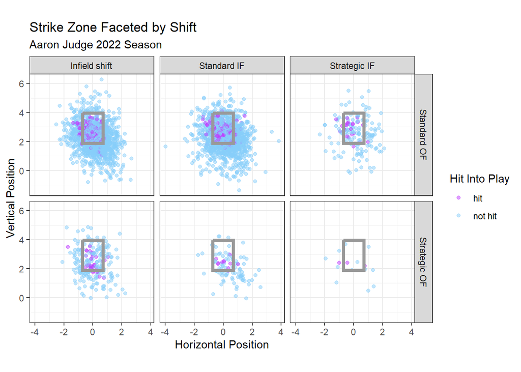

```r
judge_shift %>%
  filter(!is.na(sz_top), !is.na(sz_bot),
         if_fielding_alignment != "") %>%
  ggplot(aes(x = plate_x, y = plate_z, color = hit_into_play)) +
  geom_point(alpha = 0.5) +
  geom_zone(top = 3.96, bottom = 1.87) +
  labs(title = "Strike Zone Faceted by Shift", subtitle = "Aaron Judge 2022 Season",
       x = "Horizontal Position", y = "Vertical Position", color = "Hit Into Play") +
  scale_color_manual(values = c("darkorchid1", "lightskyblue")) +
  coord_fixed() +
  theme_bw() +
  facet_grid(of_fielding_alignment~if_fielding_alignment)
```

There are some variables not currently present in the data frame that could be interesting to look at. The first is if Aaron Judge swung at the pitch ore not. We know Judge swung at swung at swinging strikes, fouls, or pitches hit into play. Using the `mutate()` function we can create a variable called ‘swing’ that returns TRUE if the pitch resulted in one of the conditions previous listed, or FALSE is it did not. The second new variable is for scoring position. If there was a runner on second and/or third base ‘scoring_pos’ will return TRUE.

```r
judge_swing <- judge %>%
  mutate(swing = description %in% c("swinging_strike", "swinging_strike_blocked",
                                    "foul", "foul_tip", "hit_into_play"),
         scoring_pos = !is.na(on_2b) | !is.na(on_3b))
```

#### Creating Functions

We can create another function to add home plate to a visualization. We will call this `geom_plate()`.

```r
geom_plate <- function(){
  df <- data.frame(x = c(-.7083, .7083, .7083 ,0, -.7083), y = c(0, 0, -.25, -.5, -.25))
  g <- geom_polygon(data = df, aes(x = x, y = y), fill = "white", color = "gray60", linewidth = 1.25)
  g
}
```

**ggplot2** plots sequentially, meaning that the graph keeps building on top of previous layers. To make the dots around home plate visible they need to be on top of the plate. So, `geom_plate()` needs to come before `geom_point()`.

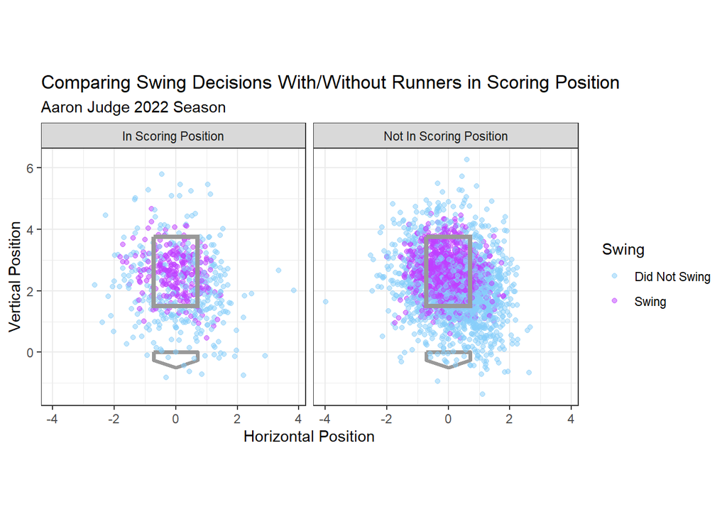

```r
judge_swing$swing <- as.character(judge_swing$swing)
judge_swing$scoring_pos <- as.character(judge_swing$scoring_pos)

judge_swing %>%
  mutate(swing = recode(swing, "TRUE" = "Swing", "FALSE" = "Did Not Swing"),
         scoring_pos = recode(scoring_pos, "TRUE" = "In Scoring Position",
                              "FALSE" = "Not In Scoring Position")) %>%
  ggplot(aes(x = plate_x, y = plate_z, color = swing)) +
  geom_plate() +
  geom_point(alpha = 0.5) +
  geom_zone() +
  labs(title = "Comparing Swing Decisions With/Without Runners in Scoring Position",
       subtitle = "Aaron Judge 2022 Season",
       x = "Horizontal Position", y = "Vertical Position", color = "Swing") +
  scale_color_manual(values = c("lightskyblue", "darkorchid1")) +
  theme_bw() +
  coord_fixed(ratio = 1) +
  facet_wrap(~scoring_pos)
```

According to the official MLB rules the strike zone is the space above home plate between the top of the batter’s shoulders and their knees. During the game there is no rectangle showing the umpire exactly what that strike zone is. Umpire’s use their judgement for what they consider a strike or a ball. Below is the creation of a variable, ‘true’, that determines if the pitch should have been called a ball or a strike. `case_when()` is used to tell R if certain conditions are met then return this. The first line of `case_when()` below is saying if ‘plate_z’ is greater (higher) than ‘sz_top’ OR ‘plate_z’ is less (lower) than ‘sz_bot’ return “ball”. Here is a visual to help reinforce:

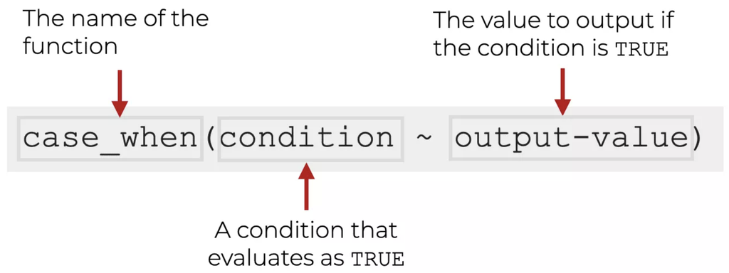

```r
calc_sz <- judge_filter %>%
  mutate(correct_call = case_when(plate_z > sz_top | plate_z < sz_bot ~ "ball",
                                  plate_x > .7083 | plate_x < -.7083 ~ "ball",
                                  TRUE ~ "strike"))
```

We will use this new variable to color the points in a graph.

[figure not shown]

```r
calc_sz %>%
  filter(description %in% c("ball", "called_strike"), !is.na(sz_top), !is.na(sz_bot)) %>%
  mutate(type = recode(type, "B" = "called ball", "S" = "called strike")) %>%
  ggplot(aes(x = plate_x, y = plate_z, color = correct_call)) +
  geom_point(alpha = 0.5) +
  geom_zone(top = 3.96, bottom = 1.87) +
  labs(title = "Called Strike Zone Colored by Rule Book Strike Zone", subtitle = "Aaron Judge 2023 Season",
       x = "Horizontal Position", y = "Vertical Position", color = "Rule Book \nStrike Zone \nCall") +
  scale_color_manual(values = c("lightskyblue", "cornflowerblue")) +
  coord_fixed() +
  theme_bw() +
  facet_wrap(~type)
```

The left graph is what the umpire called as balls, and the right graph is what the umpire called as strikes.

It would be interesting to see what the strike zone looks like according to the umpire’s calls. To do this we need to load the **ggforce** library.

```r
library(ggforce)
```

The function we need to use is`geom_mark_hull()`. Essentially it draws a line around the perimeter of the points. The ‘expand’ argument specifies how much space there should be between the points and line. The ‘size’ and ‘color’ arguments are about the appearance of the line. Following that are two functions, `xlim()` and `ylim()`, which can be used to manually specify the limits of each axis.

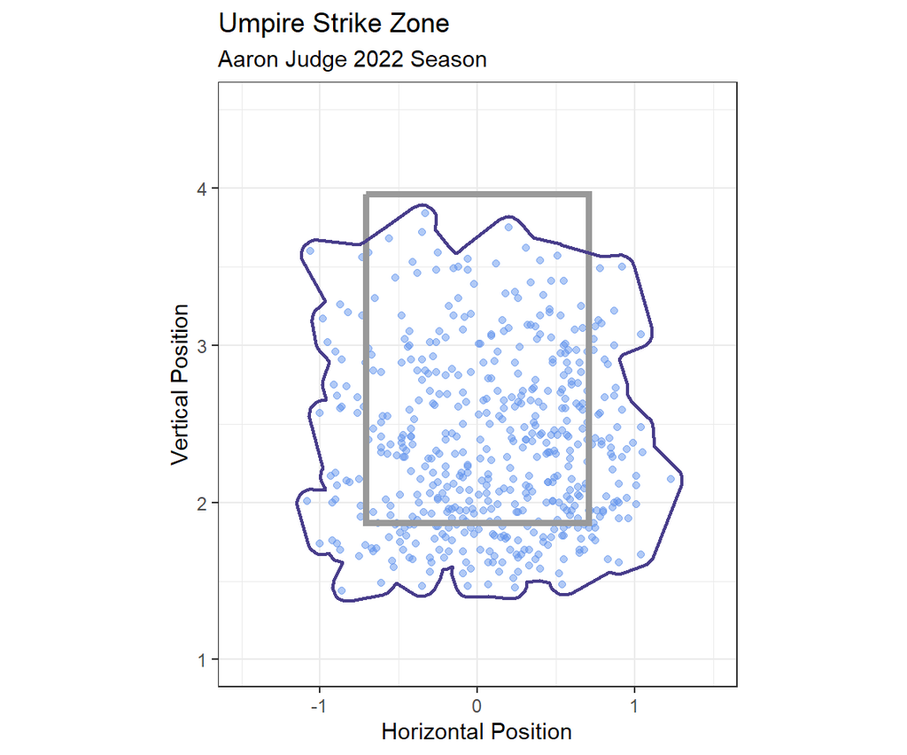

```r
judge_filter %>%
  filter(type == "S") %>%
  ggplot(aes(x = plate_x, y = plate_z)) +
  geom_point(alpha = 0.5, color = "cornflowerblue") +
  geom_zone(top = median(judge_filter$sz_top), bottom = median(judge_filter$sz_bot)) +
  geom_mark_hull(expand = unit(2, "mm"), size = .8, color = "darkslateblue") +
  labs(title = "Umpire Strike Zone", subtitle = "Aaron Judge 2022 Season",
       x = "Horizontal Position", y = "Vertical Position") +
  xlim(-1.5, 1.5) +
  ylim(1, 4.5) +
  coord_fixed(ratio = 1) +
  theme_bw()
```

Now let’s try some strike zone plots with the Mariners vs. Rays game data.

This graph shows all of the different pitch types thrown in the game and is colored by the result.

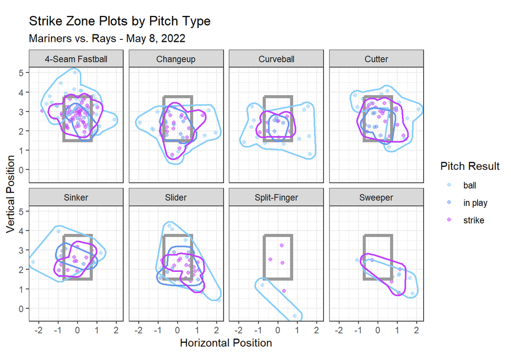

```r
game %>%
  mutate(type = recode(type, "B" = "ball", "S" = "strike", "X" = "in play")) %>%
  ggplot(aes(x = plate_x, y = plate_z, color = type)) +
  geom_point(alpha = 0.5) +
  geom_zone() +
  geom_mark_hull(aes(color = type),
                 expand = unit(2, "mm"), size = .8, show.legend = FALSE) +
  labs(title = "Strike Zone Plots by Pitch Type", subtitle = "Mariners vs. Rays - May 8, 2022",
       x = "Horizontal Position", y = "Vertical Position", color = "Pitch Result") +
  scale_color_manual(values = c("lightskyblue", "cornflowerblue", "darkorchid1")) +
  coord_fixed(ratio = 1) +
  theme_bw() +
  facet_wrap(~pitch_name, nrow = 2)
```

Now let’s look at just Kirby’s arsenal.

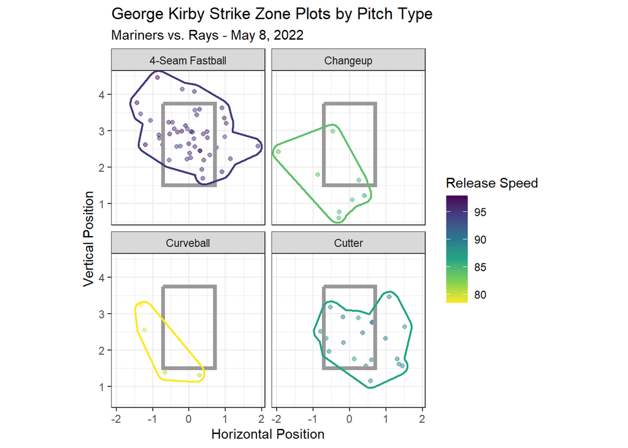

```r
game %>%
  filter(pitcher == 669923) %>%
  ggplot(aes(x = plate_x, y = plate_z, color = release_speed)) +
  geom_point(alpha = 0.5) +
  geom_zone() +
  geom_mark_hull(expand = unit(2, "mm"), size = .8, show.legend = FALSE) +
  labs(title = "George Kirby Strike Zone Plots by Pitch Type", subtitle = "Mariners vs. Rays - May 8, 2022",
       x = "Horizontal Position", y = "Vertical Position", color = "Release Speed") +
  scale_color_viridis_c(direction = -1) +
  coord_fixed(ratio = 1) +
  theme_bw() +
  facet_wrap(~pitch_name, nrow = 2)
```

He most frequently throws 4-seam fastballs. Those are his fastest pitches. Kirby only threw a handful of curveballs this game. Those were his slowest pitches.

## Pitch Release Plot

We will facet by pitcher. The data includes pitcher id, but not pitcher name. To find the name matching each id number we have to use Baseball Savant. Paste this link into your browser: https://baseballsavant.mlb.com/savant-player/ and type the player id after the last /. For example, the first pitcher would be https://baseballsavant.mlb.com/savant-player/552640. That number belongs to Andrew Kittredge. We can mutate a new variable to store these names.

```r
game <- game %>%
  mutate(pitcher_name = case_when(pitcher == 552640 ~ "Andrew Kittredge",
                                  pitcher == 592094 ~ "Jason Adam",
                                  pitcher == 605538 ~ "Matt Wisler",
                                  pitcher == 608716 ~ "Drew Steckenrider",
                                  pitcher == 621248 ~ "Ralph Garza Jr.",
                                  pitcher == 623149 ~ "Paul Sewald",
                                  pitcher == 642232 ~ "Ryan Yarbrough",
                                  pitcher == 657024 ~ "Erik Swanson",
                                  pitcher == 662253 ~ "Andrés Muñoz",
                                  pitcher == 669923 ~ "George Kirby"))
```

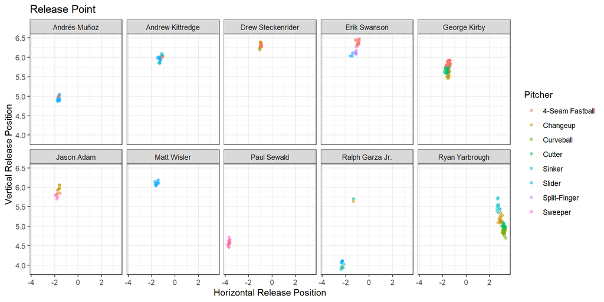

```r
game %>%
  ggplot(aes(x = release_pos_x, y = release_pos_z, color = factor(pitch_name))) +
  geom_point(alpha = 0.5) +
  labs(title = "Release Point", color = "Pitcher",
       x = "Horizontal Release Position", y = "Vertical Release Position") +
  theme_bw() +
  facet_wrap(~pitcher_name, nrow = 2)
```

From this we can see that Ryan Yarbrough’s release point is much higher when throwing a sinker than it is when throwing curveball.

## Spray Chart

Spray charts show the location of balls hit into play. One game usually produces around 250-300 rows of data. To get more data points, we will use a large data set. This data set will contain all games played on July 2, 2022 and July 3, 2022.

```r
spray <- statcast_search(start_date = "2022-07-02",
                        end_date = "2022-07-03",
                        player_type = "batter")

# filter out the NAs
spray <- spray %>%
  filter(!is.na(hc_x), !is.na(hc_y))
```

To plot a spray chart we need to used `geom_point()`.

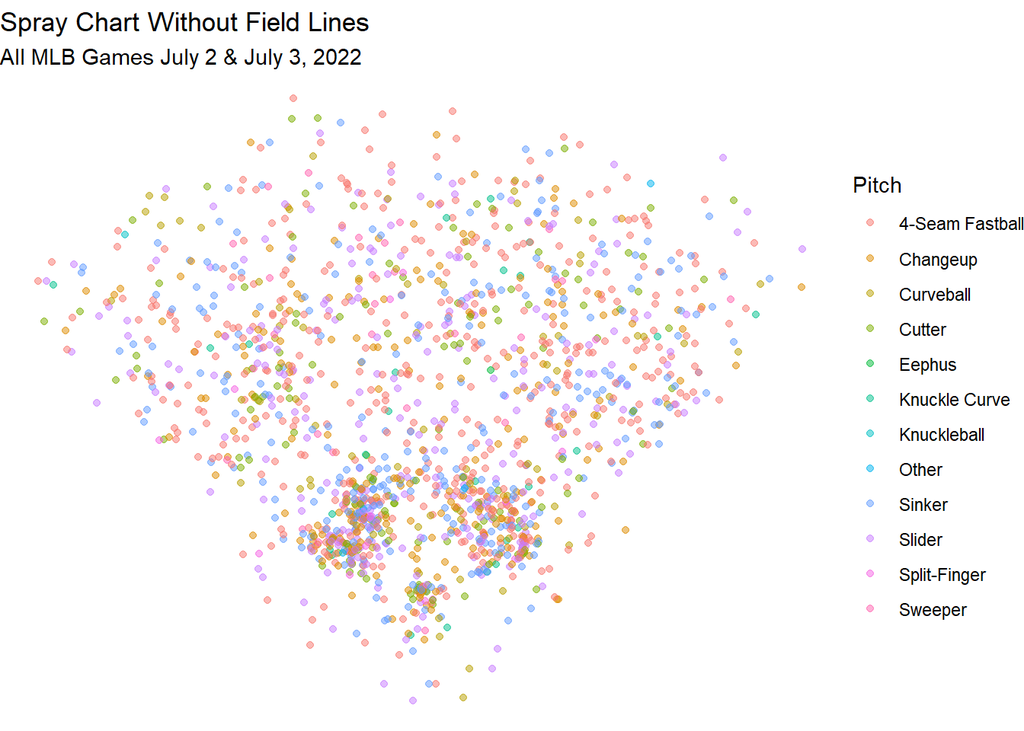

```r
spray %>%
  ggplot(aes(x = hc_x, y = -hc_y, color = pitch_name)) +
  geom_point(alpha = .5) +
  labs(title = "Spray Chart Without Field Lines", subtitle = "All MLB Games July 2 & July 3, 2022",
       color = "Pitch") +
  theme_void()
```

From the concentration of points we can get an idea of the shape of the field, but it would be nice to see the lines of the baseball field. We can create a function to do this!

#### Creating Functions

```r
geom_spray <- function(...) {
  ggplot(...) +
    geom_curve(x = 33, xend = 223, y = -100, yend = -100, curvature = -.65) +
    geom_segment(x = 128, xend = 33, y = -208, yend = -100) +
    geom_segment(x = 128, xend = 223, y = -208, yend = -100) +
    geom_curve(x = 83, xend = 173, y = -155, yend = -156, curvature = -.65, linetype = "dotted") +
    coord_fixed() +
    scale_x_continuous(NULL, limits = c(25, 225)) +
    scale_y_continuous(NULL, limits = c(-225, -25))
}
```

It is important to note that `geom_spray()` plots the lines for an *average* ballpark. Each park can differ a bit in their dimensions, but overall have this shape.

function code from pg 271 of *Analyzing Baseball Data with R*

Here is the same graph from before, but with the ballpark lines added.

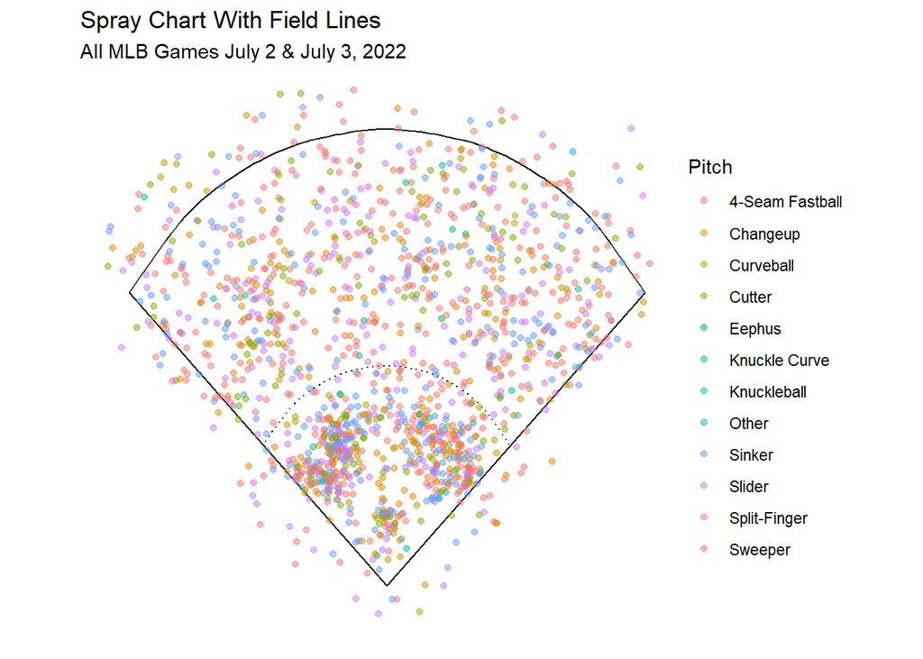

```r
spray %>%
  geom_spray(aes(x = hc_x, y = -hc_y)) +
  geom_point(aes(color = pitch_name), alpha = .5) +
  labs(title = "Spray Chart With Field Lines", subtitle = "All MLB Games July 2 & July 3, 2022",
       color = "Pitch") +
  theme_void()
```

Next let’s make a spray chart to see where Aaron Judge hits to.

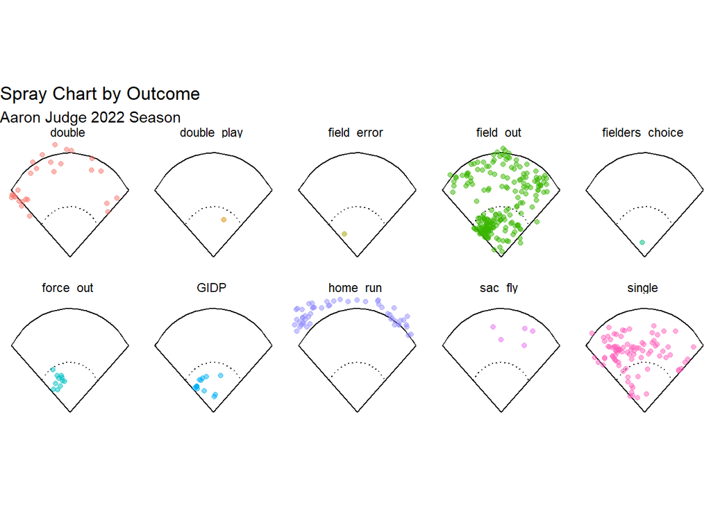

```r
judge %>%
  filter(!(events %in% c("", "catcher_interf", "hit_by_pitch", "walk", "strikeout"))) %>%
  mutate(events = recode(events, "grounded_into_double_play" = "GIDP")) %>%
  geom_spray(aes(x = hc_x, y = -hc_y)) +
  geom_point(alpha = .5, aes(color = events)) +
  labs(title = "Spray Chart by Outcome", subtitle = "Aaron Judge 2022 Season", color = "Events") +
  theme_void() +
  theme(legend.position = "none") +
  facet_wrap(~events, nrow = 2)
```

**NOTE:** this theme is cutting off the bottom part of facet labels

## Contour Plot

**What should we call these graphs? Should they be called contour plots or no because technically it’s a 2D density plot. I just didn’t want to call it a density plot because geom_density() is it’s own thing that looks very different from this, and I thought it might be a little confusing for someone just starting in ggplot.**

Couldn’t figure out how to get `geom_contour()` to work - what should ‘z’ be? reference: https://ggplot2.tidyverse.org/reference/geom_contour.html

Once we decide on what to call the graph name I’ll write a little explanation for this plot type and come up with names.

Another type of visualization we can make is a contour plot. The colors show how concentrated data points are in certain areas. We will use the function `geom_density_2d_filled()` to make these graphs.

This plot is showing Aaron Judge’s strike zone.

**Should both of these graphs be included?**

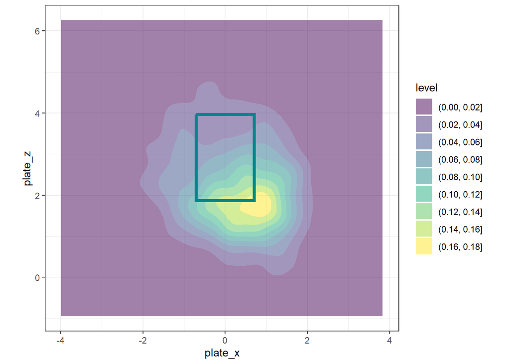

```r
judge_filter %>%
  ggplot(aes(x = plate_x, y = plate_z)) +
  geom_density_2d_filled(alpha = 0.5) +
  geom_zone(top = median(judge_filter$sz_top), bottom = median(judge_filter$sz_bot),
            linecolor = "turquoise4") +
  coord_fixed() +
  theme_bw()
```

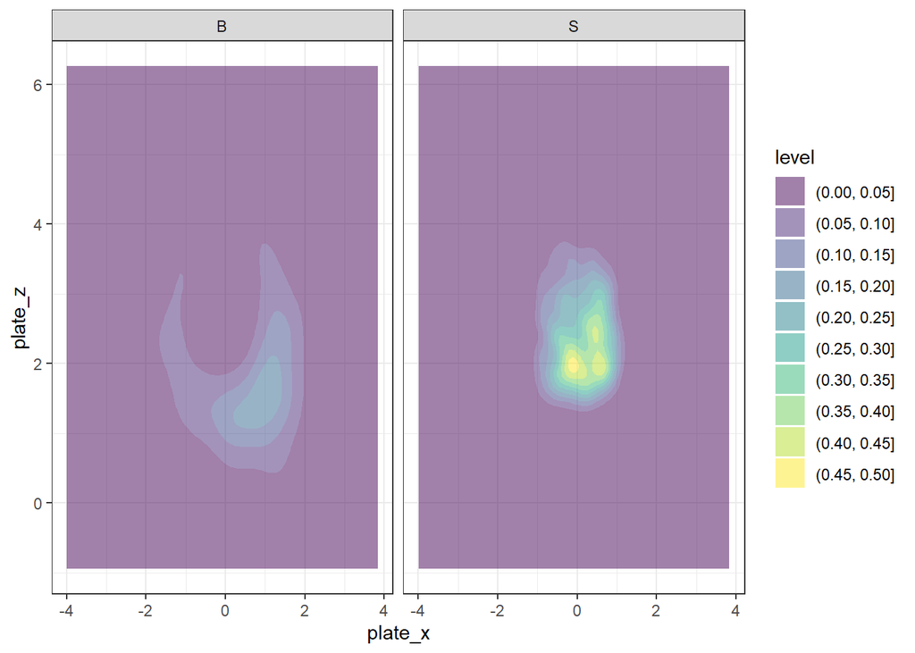

```r
judge_filter %>%
  ggplot(aes(x = plate_x, y = plate_z)) +
  geom_density_2d_filled(alpha = 0.5) +
  theme_bw() +
  facet_wrap(~type)
```

reference: https://ggplot2.tidyverse.org/reference/geom_density_2d.html#ref-examples

This graph is showing Judge’s strike zone, but only for pitches that he hit a home run on.

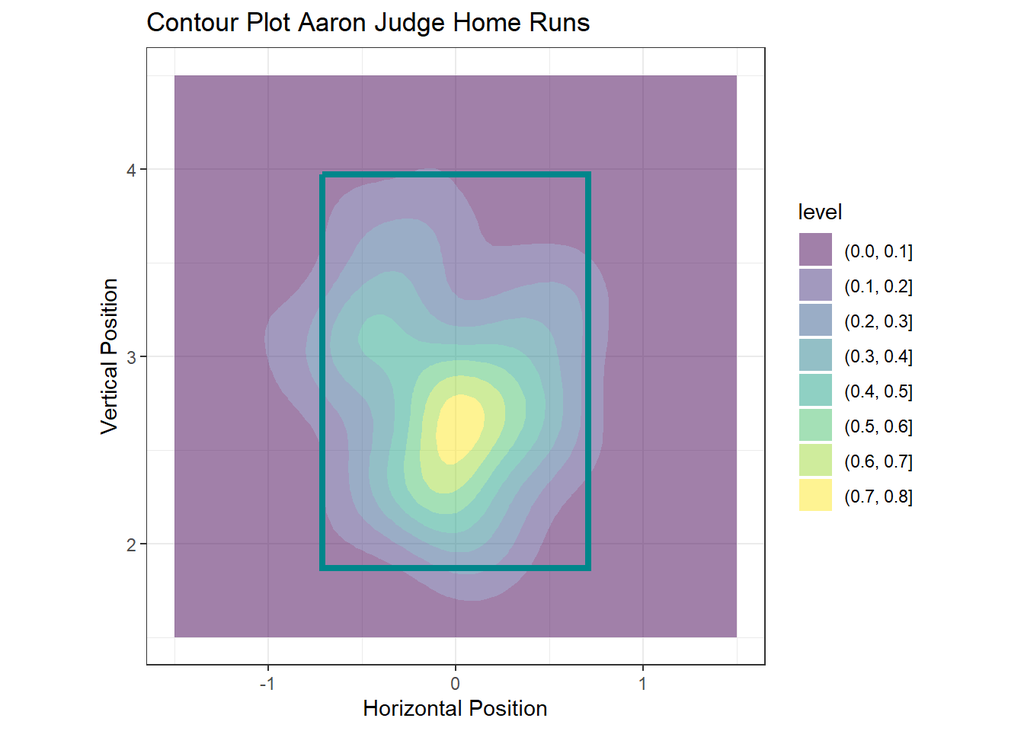

```r
judge %>%
  filter(events == "home_run") %>%
  ggplot(aes(x = plate_x, y = plate_z)) +
  geom_density_2d_filled(alpha = 0.5) +
  xlim(-1.5, 1.5) +
  ylim(1.5, 4.5) +
  geom_zone(top = 3.97, bottom = 1.87, linecolor = "turquoise4") +
  labs(title = "Contour Plot Aaron Judge Home Runs",
       x = "Horizontal Position", y = "Vertical Position") +
  coord_fixed() +
  theme_bw()
```

The yellow indicates a that many of the pitches Judge hit a home run on were in the middle of his zone.

Sometimes it can be helpful to look at two plots side-by-side. We can do this using the **patchwork** package.

```r
library(patchwork)
```

It is a simple process. Save each graph as an object, then write `graph1 + graph2` with your graphs names.

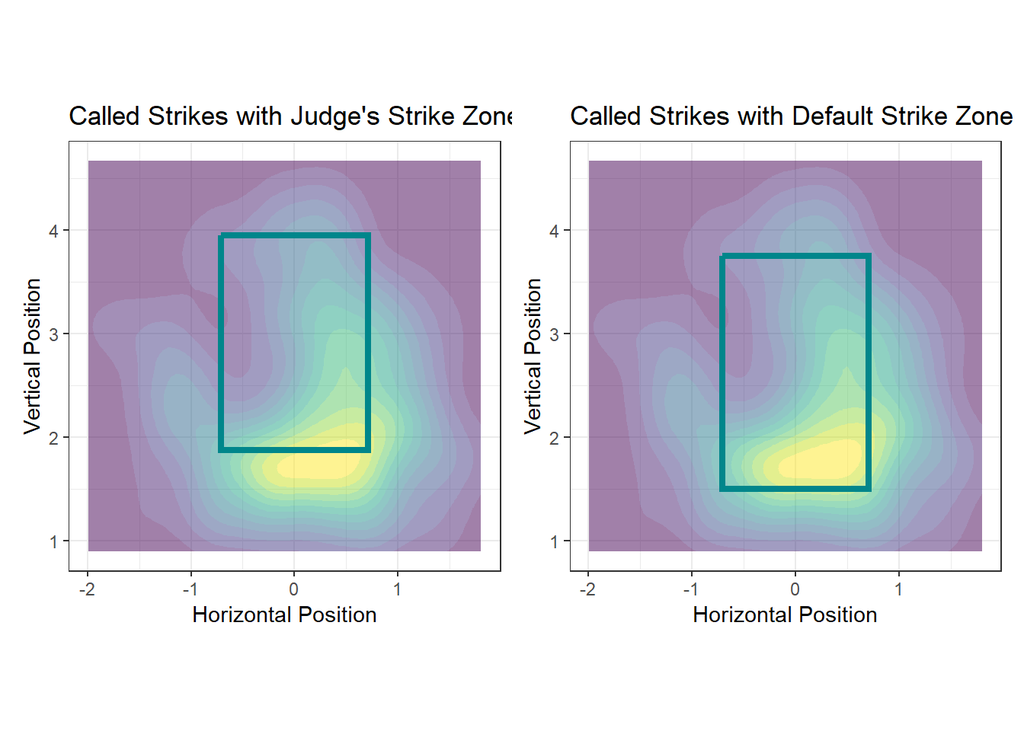

```r
g1 <- judge %>%
  filter(!is.na(sz_top), !is.na(sz_bot)) %>%
  filter(description == "swinging_strike") %>%
  ggplot(aes(x = plate_x, y = plate_z)) +
  geom_density_2d_filled(alpha = 0.5, show.legend = FALSE) +
  geom_zone(top = 3.95, bottom = 1.87, linecolor = "turquoise4") +
  labs(title = "Called Strikes with Judge's Strike Zone", x = "Horizontal Position", y = "Vertical Position") +
  coord_fixed() +
  theme_bw()
g2 <- judge %>%
  filter(description == "swinging_strike") %>%
  ggplot(aes(x = plate_x, y = plate_z)) +
  geom_density_2d_filled(alpha = 0.5, show.legend = FALSE) +
  geom_zone(linecolor = "turquoise4") +
  labs(title = "Called Strikes with Default Strike Zone", x = "Horizontal Position", y = "Vertical Position") +
  coord_fixed() +
  theme_bw()
g1 + g2
```

Contour plots can also be applied to fields.

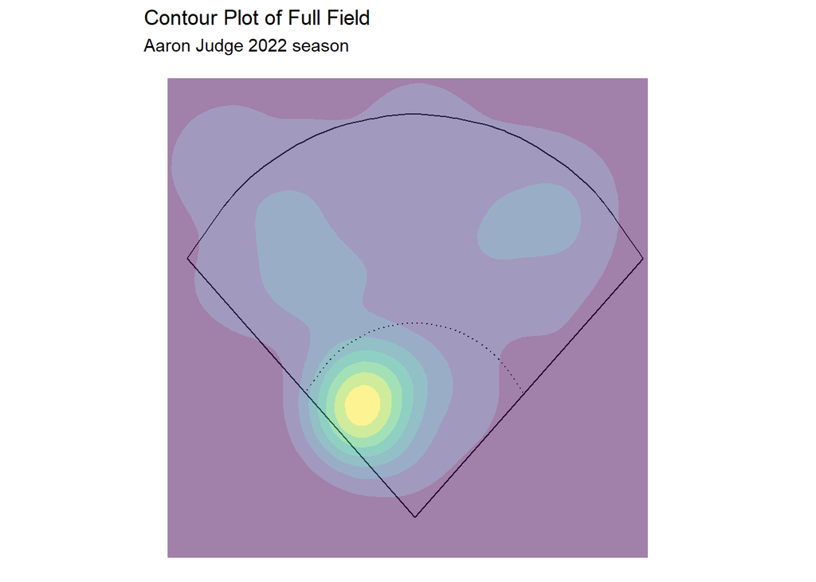

```r
judge %>%
  geom_spray(aes(x = hc_x, y = -hc_y)) +
  geom_density_2d_filled(alpha = 0.5, show.legend = FALSE) +
  labs(title = "Contour Plot of Full Field",  subtitle = "Aaron Judge 2022 season") +
  theme_void()
```

Judge most frequently hits to third base. His longer hits are typically to left or right sides of the outfield.

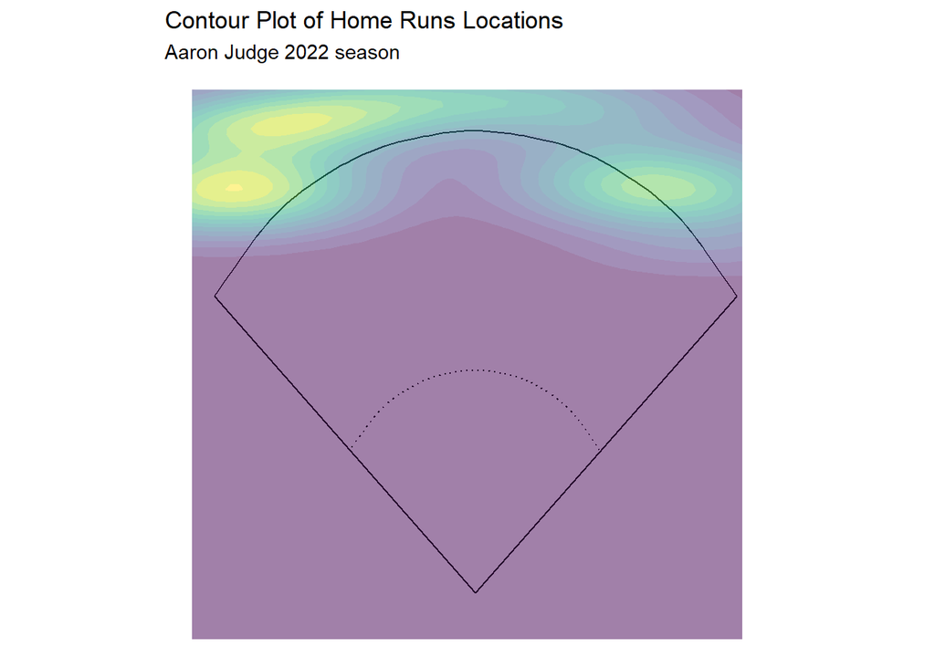

```r
judge %>%
  filter(events == "home_run") %>%
  geom_spray(aes(x = hc_x, y = -hc_y)) +
  geom_density_2d_filled(alpha = 0.5, show.legend = FALSE) +
  labs(title = "Contour Plot of Home Runs Locations",  subtitle = "Aaron Judge 2022 season") +
  theme_void()
```

A contour plot of just home runs supports the idea that Judge hits more to the outsides of the outfield than the center. He specifically favors the left.

## Heat Map

Lastly, we will make a heat map. Heat maps work in a similar way to contour plots in the sense that a continuous scale of colors represent a variable. The function for this is `geom_tile()`. To control the colors of the plot we will use `scale_fill_gradient2()`. The `scale_x_continuous()` functions lets you specify what year should be used for the ticks on the x-axis.

We will use the Lahman package to get each MLB team’s season record for the last nine years.

```r
library(Lahman)

records <- Teams %>%
  filter(yearID >= 2013)
```

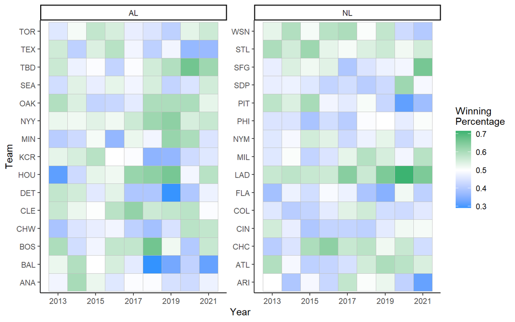

```r
records %>%
  group_by(yearID, franchID) %>%
  mutate(win_perc = W/G) %>%
  ggplot(aes(x = yearID, y = franchID, fill = win_perc)) +
  geom_tile(color = "gray") +
  labs(x = "Year", y = "Team", fill = "Winning \nPercentage") +
  scale_fill_gradient2(mid = "white", low = "dodgerblue", high = "mediumseagreen", midpoint = 0.5) +
  scale_x_continuous(breaks = c(2013, 2015, 2017, 2019, 2021)) +
  theme_classic() +
  facet_wrap(~lgID, scales = "free_y")
```

**Additional Resources on Visualizations:**

The [**CalledStrike**](https://bayesball.github.io/Intro_to_CalledStrike_Package.html) package has functions to create more types of baseball visualizations.

It is possible to create animated graphics. One example where this could be helpful is when looking at changes over a time frame. The [**gganimate** website](https://gganimate.com/) has lots of explanations and examples.